# Quality Assurance - Fundamentals

# 1 Learning Objectives

After this module you will:

- Understand what predictive modelling is
- Be aware of the major motivations and approaches in predictive modelling
- Understand the difference in focus between prediction and inference tasks
- Be aware of the different steps in a predictive modelling workflow
- Be familiar with different types of model
- Be prepared to work through the following modules

The purpose of this module is to ensure a baseline level of knowledge before the learning about the quality assurance of predictive modelling systems in the following modules.

It is recommended that you have experience in statistics / data science before completing this course, although it is not necessary to understand the fundamentals module.

# 2 What is Predictive Modelling?

> Predictive modelling is the design and use of a model with a purpose of predicting values.

## 2.1 Terms

This is quite a broad definition intentionally, predictive modelling covers a wide range of domains, and therefore has a range of potential names.

These include but are not limited to:

- Predictive Analytics
- Statistical Learning/Modelling
- Machine Learning
- Automated Decision Making
- Data Science

Each of which describe slightly different subjects and approaches to this topic, with different histories and techniques attached.

In general, all of the above are related to data and analysis, so we are going to group them up into “Data Science”. Trying to pin down a distinction between statistics and data science is worth a module in of itself, for now we will make this claim for ease of understanding. There are key, interesting distinctions in approaches between fields, but this discussion is beyond the scope of the course.

This module, and specifically this chapter will use the terms interchangably. The focus however, will be on statistical and machine learning techniques.

We will not look at any one of the domains this topic is born from in detail, but it is useful to see where predictive modelling has inherited its techniques from.

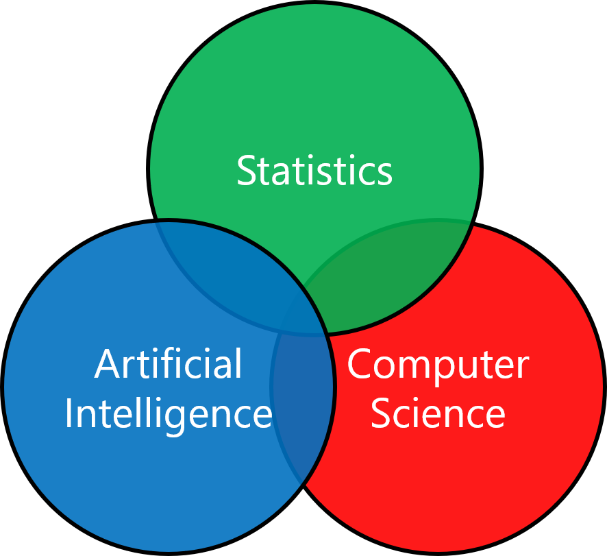

Figure 1.1: Predictive Modelling involves a variety of subjects. Mathematics underpins all of the mentioned disciplines and domain expertise relating to the topic area being predicted is crucial.

The definition of predictive modelling refers to predicting “values” - in our discussion we will focus on the prediction of numerical values (called a regression task), and discrete values, such as categories (called a classification task).

For simplicity’s sake we will stick to these classification and regression tasks throughout the course. Most prediction tasks fall into these categories. The approaches we will look at generally fall under the category of “supervised learning” - a subset of statistical / machine learning. The concepts are relevant to other topics.

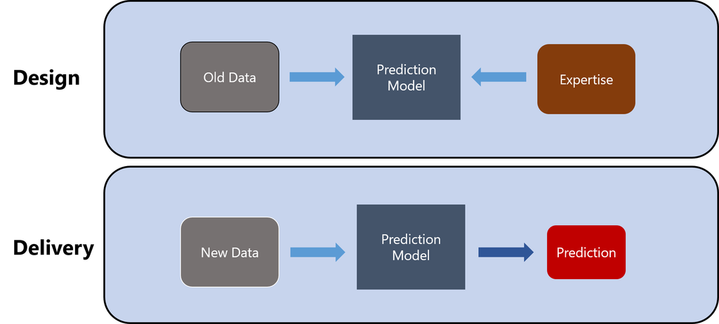

Figure 1.2: The purpose of predictive modelling is to create predictions. The model is designed, then used to deliver these predictions. The design/delivery pattern can be conducted in a range of ways.

The above diagram is the ideal scenario. How the expertise vs. use of data is weighted can depend on the scenario. What is most crucial is that a person with experience in the domain of application is involved in the model design process. In addition, expertise is needed from the people creating the model system, be it in advanced statistics, machine learning engineering or software development.

## 2.2 Algorithm vs Model

The two words are often used interchangeably, and while highly related (you need one to create the other, for example) they need to be separated.

An algorithm is “a set of rules that precisely defines a sequence of operations”. So a recipe is an algorithm, computer code can represent the implementation of an algorithm.

A model (in the mathematical sense) is a way to represent a system in a quantitive way.

Algorithms are therefore a very general concept that can be applied to many things, especially when talking about maths and code.

A model represents our beliefs about some system, allowing us to extract information from the system, or use it to predict something.

Below are some statements about algorithms and models:

- We can use an algorithm to create a model
- When we use a model in a system, as a whole that system is an algorithm
- We can create an algorithm to make predictions, that may or may not be using a model

It is therefore important to note whether or not the system you are examining has a model within it.

If it has a model in it, we need to check the quality of that model. We want to know how that model was arrived at. We then need to understand how that model is used in the algorithm.

If it does not have a model within it, then we can clearly see the steps in the algorithm to understand what it does. We will still need to understand the algorithm as a whole.

## 2.3 Guidance

This course is intended as learning material to help improve your understanding of important concepts relating to predictive modelling and ensuring it is high quality. It is not intended as a comprehensive piece of guidance. However, where relevant, this course will highlight existing guidance and good practice.

The purpose of this course is not to replace any guidance, but to improve skills so the guidance can be more easily followed.

The primary guidance relevant to all analysis in government is [“The Aqua Book: guidance on producing quality analysis for government”](https://assets.publishing.service.gov.uk/government/uploads/system/uploads/attachment_data/file/416478/aqua_book_final_web.pdf). This should be your first port of call for guidance in analysis. This course will use principles from this book, with a focus on predictive modelling and machine learning.

Further resources related to The Aqua Book, with more specific good practice elements can be found on the [page for Aqua Book resources](https://www.gov.uk/government/collections/aqua-book-resources).

Modern predictive modelling relies heavily on the use of code, and as such good practice in programming and quality assurance of code should be followed. More information about this guidance can be found in the [“Quality Assurance of Code for Analysis and Research” book](https://best-practice-and-impact.github.io/qa-of-code-guidance/intro.html).

In addition, there is the:

- [UKSA Ethical Principles](https://uksa.statisticsauthority.gov.uk/about-the-authority/committees/national-statisticians-data-ethics-advisory-committee/ethical-principles/)
- [Ethics, Transparency and Accountability Framework for Automated Decision-Making](https://www.gov.uk/government/publications/ethics-transparency-and-accountability-framework-for-automated-decision-making/ethics-transparency-and-accountability-framework-for-automated-decision-making)

## 2.4 Modelling Principles

For all modelling tasks we need to understand what modelling actually is.

Crucial to modelling is the simplification of reality. In order for our model to have value it must be easier to understand or work with than the actual raw data or phenomena it is based on.

When we model we make assumptions about data, structure and processes. These assumptions reduce the complexity, which means some information is lost.

This is well described by a quote attributed to George Box:

> “All models are wrong, but some are useful”

Which nicely encapsulates the challenges with modelling.

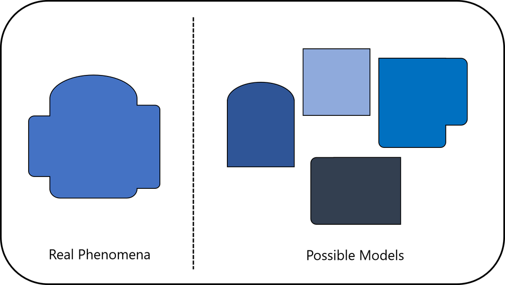

Figure 1.3: We cannot fully represent complex phenomena in a model, but the models we can pick may be useful for different predictions.

This simplification has some effects on predictions:

- Our models will never be able to predict outcomes perfectly.
- Different models will simplify reality in different ways - this will cause the models to be better in some situations than others.
- The more simplified the model, the easier it will be to understand why a prediction was made.
- The more complex the model, the closer to reality we can model.
- If we know our model is going to be wrong, we need to maximise how useful it is.

An appreciation that no modelling, by definition, can be perfect is important as we move towards checking the quality of predictive models.

## 2.5 Rules-Based vs Learned models

Before we go into the discussion about models learning how to predict, it’s best that we understand what this means, and contrast this with other decision-making processes.

There are *generally* two ways to produce an algorithm for decision-making.

The first is using a “rules-based approach”, the second is to have a model “trained” to make decisions.

Consider the following case study:

> You have been tasked with creating an algorithm which decides whether an expenses claim in your department should be reviewed. This algorithm will be applied to all expenses claims that are received. The algorithm labels each claim with “review” or “no_review”. This is being done in order to reduce the amount of manual checking of each claim by the finance team.

### 2.5.1 Rules-based approach

To tackle this problem with a rules-based approach we would need to create a set of rules which would lead to a decision of “review” or “no_review”.

To come up with these rules we need to really understand the phenomena, what does an error in a claim look like? What information available can we use to make accurate decisions from? What do the experts in the finance team think the rules should be?

We may end up with rules along the lines of:

- “review” if claim > £100
- “review” if first claim from the individual
- “review” if claimer has claimed > £1000 in the past month
- “review” if claim contains the word “alcohol”, “beer” or “wine”
- “no_review” otherwise

This will give our algorithm (or person) a flow chart to follow when making this automated decision:

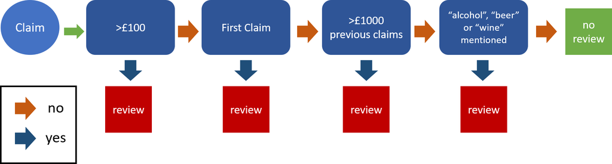

Figure 1.4: A decision flow chart representing an agorithm for classifying expense claims. We can see what is happening at each step.

This process is clear, we can see why an individual decision has been made, but why are the rules the way they are? The rules could be decided based on experience of an individual, through analysis or intuition. However, coming up with the rules requires knowledge and expertise, and the rules might not even be hugely effective. We are limited in the complexity we can model this way.

We could evaluate this rules-based system against whether an expert has decided a claim should be reviewed or not “labelling” it. We could then tweak our rules such that the system predicts more “review”/“no_review” choices correctly. But this process is manual, requiring significant manual intervention and not necessarily producing a good result.

For example, given the above rule set, I could put my claim in for “booze”, at £99, ten times per month and not trigger a review of my claims.

We need a less manual approach to finding these rules, which can capture far more complex relationships between data without us needing to explicitly create rules.

This is where model learning comes in.

Instead of setting the rules ourselves we can set:

- a goal (maximise the number of correct predictions)
- example data (previous claims and their “review”/“no_review” labels)
- a learning algorithm

The learning algorithm will then learn a model, a set of rules, which performs against the goal it was given based on the data it has seen.

In our example, the model will create a function which:

- takes in the claims data
- uses the variables from the data, transforms / weights the variables
- produces a prediction of “review”/“no_review”

The resulting model can represent more complicated relationships than our rules-based approach. The model may note that claims are more likely to need review if the person claims late in the day, but not when submitted on a Friday. By producing this model we could learn that a better value of claim to predict a review is actually £56.12, and that the best word to check for is actually “stationary”. The amount of investigation and manual tuning to find these rules ourselves would be prohibitive, especially for data with lots of variables or large numbers of samples.

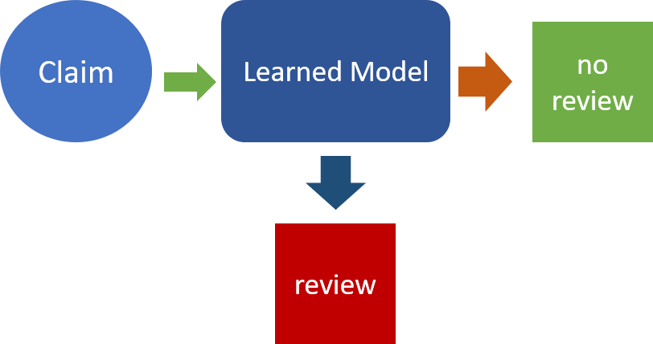

Figure 1.5: The learned model will contain variable weights, probabilities or other quantities depending on the model used which when brought together will give a prediction for an individual claim.

In a range of applications, using these learned models can increase the performance of a system above that of a rules based approach substantially.

It is still important to us, however, that we can understand what the learning algorithm has produced. Without understanding what rules have been found by the algorithm we can’t learn from it, or be confident about it’s quality.

The above case study doesn’t mean that rules-based decision-making is better than learned models, it just means that learned models can add value in some systems, particularly those:

- Where there are no simple rules
- Where processes are evolving, it’s not practical to keep writing new rules
- Where complex data is involved, such as text, video, images or high numbers of variables

## 2.6 Discussion

**Question**

If you were trying to predict a given house’s price, what data could be useful to do this with?

**Suggestions**

We would need data that contained the price of specific houses.

Data about each individual house and it’s attributes would be helpful. What do we think causes house price? Quantities such as number of rooms, size, whether it has a garden and age could help predict price.

Using the location of the house could yield interesting results. From location data we can link in other attributes of the house, such as:

- How far it is to transportation links
- Local economic indicators, such as the index of multiple deprivation
- Local health
- Local average rent / property values

## 2.7 Optimization Basics

Problems which use learning algorithms to find a solution are, in their core, optimization problems. Understanding how optimization problems works is helpful when looking at automated decision-making / machine learning systems.

The first step in understanding the incentives and influences on a model is seeing that a model is rarely ever just a mathematical formulation. The context of why the model is being created, the design decisions made, the resources required to create it and they way in which it will be used are all real world factors that influence choices made in designing the model. These considerations cannot and should not be excluded when looking at modelling. By taking these wider considerations we can produce *better* models, more aligned to their tasks.

Prediction models are part of systems, the system should be explored in full, rather than in isolation of external factors.

An optimization problem has a number of characteristics:

- An objective
- A range of possible approaches
- Constraints

The objective is quantifiable, allowing us to have “degrees of success”. A quantification of an objective in this way is referred to as the “objective function”.

There needs to be a range of possible choices or approaches that can be taken, it is our role to find which approach is best, based on how well it performs against the objective.

Constraints prevent some possible choices or approaches from being taken. Constraints can be caused by factors outside of the modelling process, or limits imposed by choice.

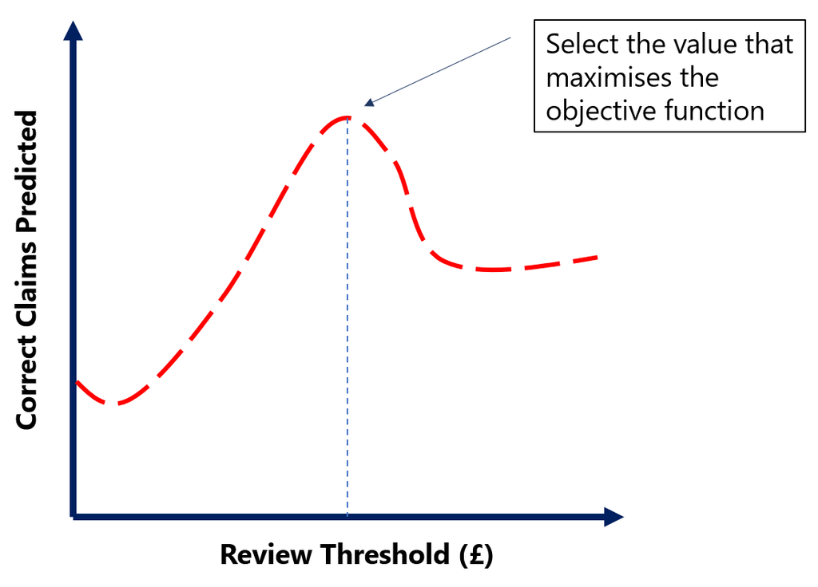

Figure 1.6: An example objective function for the claims review task, an optimal value for the model can be made based on the maximum of the function.

### 2.7.1 Example Objectives

- Maximize how correct a weather prediction is
- Minimize the number of incorrect addresses matched
- Maximize number of purchases on a website

Notice how we could switch any of the maximises/minimises and negate the text and still have the same result. A maximisation problem is just the opposite of a minimisation problem, we can convert between the two by changing the wording of a sentence, such as switching “incorrect” to “correct”.

This represents the difference between an “objective function”, or “utility function” - something we want to maximise generally, and a “loss function”, something we want to minimise. In practice, the difference is normally just a negative sign. We will use the terms interchangably later in the course.

There too can be multiple objectives, which can be conflicting with each other. For example trying to maximise the number of errors caught in a process conflicts with minimising the time spent reviewing errors. Where multiple objectives exist there will be a tradeoff between them that needs to be decided.

### 2.7.2 Example Constraints

- Time / Budget / Resources
- Performance - how good does the result need to be?
- Interpretability - how clear does the result need to be?
- Information
  - Can the data needed be found?
  - Can privacy protection be followed?

The above are all real world potential constraints which impact the final system design we choose. If there were no constraints then choosing which model / process to follow would be quite simple. Reality is rarely that simple, and these constraints introduce tradeoffs which can lower objective performance.

It is crucial to understand what constraints exist, or should exist, on a system before attempting to learn a solution.

If we impose different contraints on our system (such as lower ethical standards, higher cost, lower interpretability) we will get a different solution.

Our role is therefore to find the right decisions / choices / models which maximise the objective while adhering to the constraints of the task. There will not be one “best” answer, but a set of good answers for the given constraints and goals.

Thankfully, maximising some numeric quantity (the objective function), can be done much easier by computers than humans.

## 2.8 Prediction vs. Inference

There are, very broadly, two tasks for which modelling can be used: prediction and inference.

For the purpose of this course we are going to define them as:

- **Prediction** - build a model that is able to produce an expected outcome for new data
- **Inference** - build a model that gives us insight about a data generation process

An example prediction would be to predict whether a customer is likely to renew a subscription based on their service usage.

A data generation process is just a system, or population which produces things we can record as data. We could try to perform causal inference to determine whether some treatment has an effect; did a medicine work on the patients? Or we could perform inference to try understand the factors that affect an outcome, such as an analysis of weather patterns and their impact on ice cream sales.

**These two tasks are not exclusive.**

In this course we are focusing on prediction - however, there are key differences and relationships with inference that are important to highlight. *Very* broadly, we will make sweeping statement that prediction is the focus of machine learning, and inference is typically the focus of statistics.

Therefore, an important question for us to answer when doing modelling is:

> Is our focus on prediction or inference?

Note that this is not a binary choice between prediction or inference, but rather a question of what is the focus.

In practice, we want (hopefully) a balance of the two. What that balance is depends on our use case.

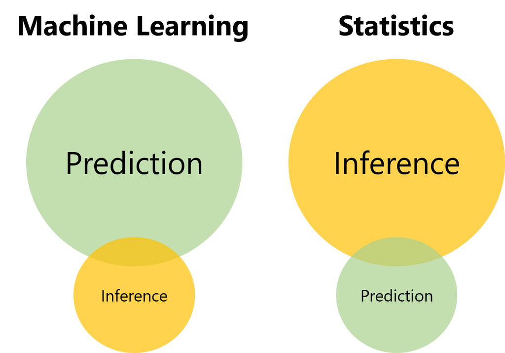

Figure 1.7: Depending on the task we may focus more on understanding how the data was created with a model (inference) or predicting values for new data points (prediction).

Consider the the two extremes:

- High prediction no inference - a blackbox model. We can make good predictions, but do not learn anything about the data generation process.
- High inference, poor prediction - a simple model. We can understand the factors in the data generation well, but our simple model may miss out on complex phenomena causing poor prediction.

If we want to make good predictions (the point of this course), but also understand more about the data generation process we are modelling, we fall in a region between these two extremes.

Deciding to focus on prediction or inference will lend our approach towards slightly different sets of tools, as we have different goals. Very broadly, this a distinction between statistical modelling and machine learning.

Below are some key differences, and the effects of the difference in emphasis between prediction and inference modelling.

### 2.8.1 Evaluation

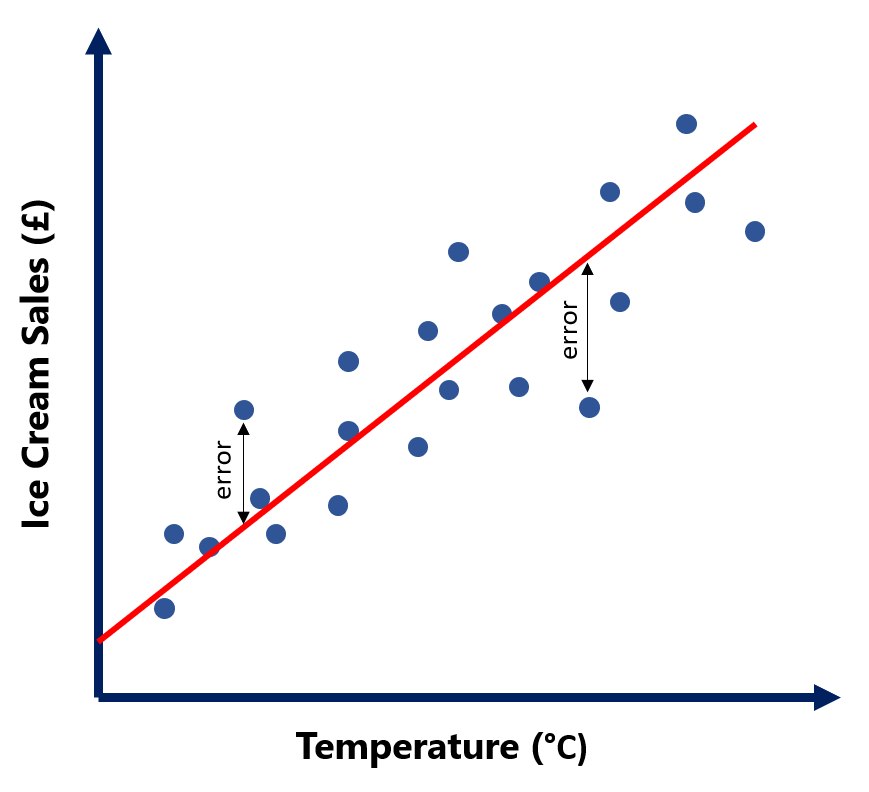

Figure 1.8: For prediction we want as small a prediction error as possible, for inference we want as good a fit as possible. Often, this can mean the same thing.

The two tasks are often evaluated differently.

- Prediction models - evaluated on the quality of their predictions
  - How correct are the predictions of the model? What errors does the model produce when using real data? How does the model perform on different parts of a data set? We need to have a **ground truth** to compare the model predicted values with.
- Inference models - evaluated using a goodness of fit measurement. Hypothesis tests can be used on the model to determine how well the model explains the data it is given.
  - How much of the variance is explained by the model?

These two approaches are both useful for evaluating a model’s performance in a task. In prediction tasks there is often less of a focus on confidence intervals (not all prediction models can produce these) and statistical hypothesis tests. The focus is instead in reducing the error in prediction of the model.

### 2.8.2 Occam’s Razor

It wouldn’t be a modelling course without briefly mentioning Occam’s Razor, or, the Law of Parsimony.

> “Entities should not be multiplied without necessity” - the simplist explanation is usually the correct one

This is an alluring principle - the best solution is often the simplest.

For inference problems this is often the case, our data generation problem can often be explained approximately by a simple model.

However, for a prediction model, the simple solution will often not produce the best set of predictions. Adding in more complexity to a model - by adding more variables or relationships between variables, can often improve our model’s ability to predict.

We then get a tradeoff which will be a reoccuring theme of this course. The more complex a model, often, the more challenging it is to understand the underlying process that is being modelled. We will tread carefully in this area, for now it is adequate to understand that Occam’s Razor is a useful principle, but when our goal is to predict a complex outcome, it may not be as useful as it is in inference tasks.

If we only measure a model by how well it predicts, we will often end up with complex models. If we constrain our model such that it needs to be simple, we may not predict as well, but will be able to understand the resulting model better.

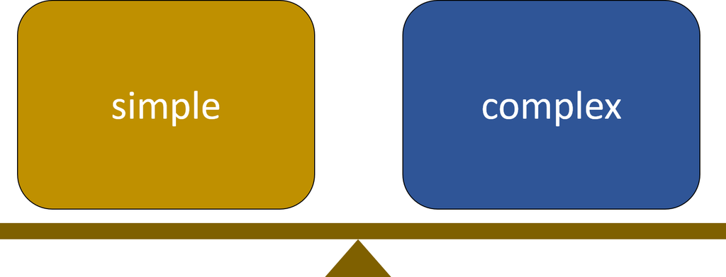

Figure 1.9: Simple models are often easier to explain and preferred in inference tasks. More complex models are often harder to explain, but can produce better predictions.

### 2.8.3 Overfitting

Overfitting is a common issue in predictive modelling. Overfitting is when a model learns about the data it was trained on **too well**. The model becomes excellent at predicting data it has already seen, but really bad at predicting new data unlike what it was trained on. When a model is overfit we say it will not “generalise well” to new data.

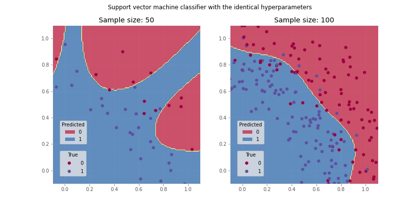

Figure 1.10: The model on the left has fit too close to the training data to learn a good trend, it is overfit.

This problem occurs when we use highly complex models, and can actually reduce the performance of a model if not tackled properly. We will discuss this more in later modules.

[figure not shown]

Figure 1.11: This bed fits too close to an individual example of training data (someone sleeping) to be useful for general purpose.

### 2.8.4 Curse of Dimensionality

High dimensional data (think: large number of columns) can be challenging to analyse and infer information about. Consider how you would visualise data with 100 columns? We can visually only see up to three dimensions of data (without using techniques to compress information).

As data becomes high dimensional it generally becomes sparse, in that there is a wide range of possible combinations of values, but few instances.

As the number of dimensions in our data increase, the complexity of possible relationships increases, meaning we often need more complex models to explain all phenomena.

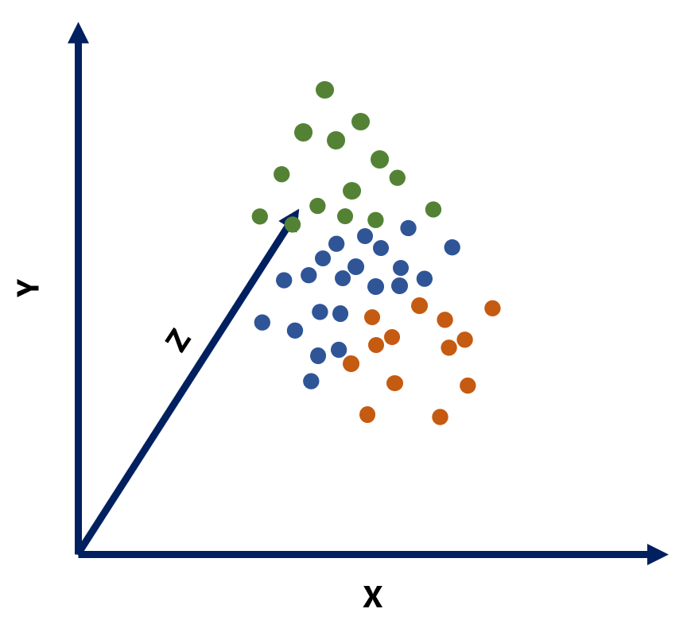

In both inference and prediction the curse of dimensionality can be an issue. The first way to tackle this problem is to gather more data, specifically more records.

However, in prediction, as we are not trying to gain information from the data, but rather generate a prediction we can use methods that harness the high numbers of dimensions to improve prediction performance.

Many types of machine learning models are intended to tackle the problems of high dimensional problems. The results of these models will however be hard for us to intuitively understand, but can generate good predictions.

### 2.8.5 Interpretability

Interpretability of models is a substantial subject, it is therefore addressed more thoroughly in later chapters.

For now we will use the loose definition: “Can we understand why a decision was made by a model?” - based on the inputs we gave it why did it give us the output we recieved?

We do not necessarily, although it is helpful, understand how a model learned its rules, but for a model to be interpretable we need to be able to, for a given data point, understand why the output is what it is.

To do this the model needs to have some characteristics (such as weights, probabilities or rules) which are understandable by humans. For each data point we can then work out what the result will be.

> Being able to **explain** how a model works is only possible for some models. We can interpret to varying degrees the outcomes of all models. A model that is explainable is inherently interpretable. If we have the option of an explainable model, we should take it!

The point of inference is to learn about the data itself. Therefore, when modelling for inference being able to understand what the characteristic values of the model tell us about the data. The weights will have a meaning which explains how the data is related / generated. Almost by definition our inference models need to be interpretable. A not interpretable inference model will not tell us anything.

This is not quite the same for prediction tasks. It is not a hard constraint on our prediction system by definition.

If we measure how well a prediction model works by it’s predictive performance (errors produced), we do not necessarily need to understand why it made a certain prediction.

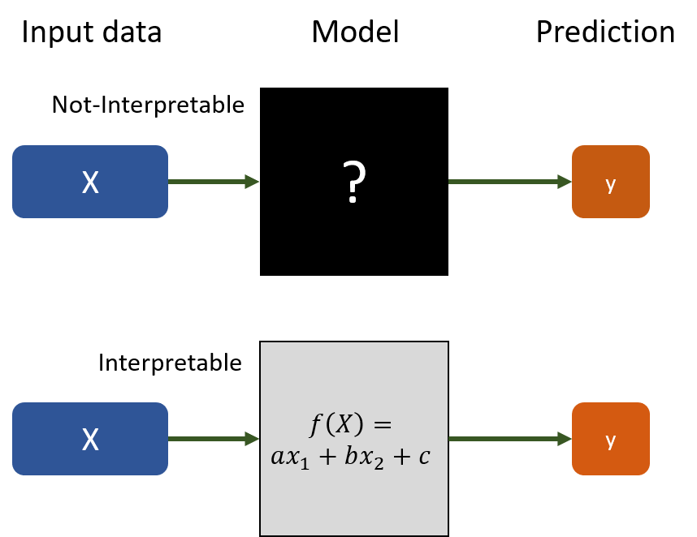

Figure 1.13: Some models will be difficult to interpret their results from, they may perform well. Other models can be easier to interpret, allowing us to more transparently work.

Highly complex models will be harder to interpret, but may have better predictive power. Interpretability isn’t therefore a **strict** requirement for prediction models, however, it is something that should be aimed for.

How interpretable we make a model is therefore a constraint on our design process.

In later chapters we will discuss what this means in practice, and the difference between explainability and interpretability.

## 2.9 Discussion

**Question**

Should predictive models be interpretable?

**Suggestions**

Predictive models *can* be interpretable, whether or not we want them to be is up to us.

If interpretability is important to us in a certain context, then yes! If interpretability isn’t important to us, then probably yes but not definitely.

What “interpretable” actually means can depend on many factors.

Some models, such as those using images or text may be harder to interpret inherently because of the complexity and size of data involved. We should make every effort to understand these, but it will not always be possible to make them fully “clear box” for all model types.

# 3 Design Workflow

In this section we will briefly outline a design process in a machine learning prediction workflow. This will help us highlight important areas for quality assurance, and allow us to look at certain steps in later chapters.

There is not one standard way to go about a machine learning task, but this example will touch on the relevant areas to prepare for further discussion.

**Quality in a system needs to be throughout the whole workflow, not just the modelling.**

Bias does come from data, but crucially it can appear in any step of the process, poor evaluation or problem identification can introduce significant bias into a system. Design choices impact the final model substantially, the decisions made need to be clearly communicated by an analyst.

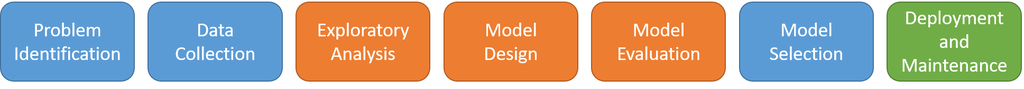

Figure 1.14: No prediction system exists in isolation, or only impacts the work of one team. Domain experts, model designers, commisioning leaders all need to be involved at various stages of the process, from conception to maintenance.

The design process is iterative, and not necessarily always in a simple sequence. More about the problem is learned at each step, which may change previously made decisions.

The Aqua book sets out three roles which are required for for effective analysis.

- **Model Commissioner** - ensures analyst understands the question/task, ensures adequate resources are allocated to provide a quality analysis, ensures risks are understood.
- **Analytical Assurer** - senior analyst/project manager not involved in model production. Ensures evidence of quality present throughout analysis lifecycle. Ensures appropriate quality assurance steps have been taken, is responsible for advising commissioner on the quality of analysis.
- **Analyst** - produces the model requested from the commissioner, ensures adequate documentation and understanding of the outputs is given to all involved.

These roles are far better explained, and the reasons for them in [the Aqua Book, sections 2.11-2.23](https://assets.publishing.service.gov.uk/government/uploads/system/uploads/attachment_data/file/416478/aqua_book_final_web.pdf).

For predictive modelling there will be some additional people involved, there is no one way to organise the roles, but understanding the different inputs individuals can have is useful. We want to avoid separating the analyst (model builder) from the business problem as much as possible.

- **The data manager** - is responsible for obtaining data used to train the model. It is not always the case that the owner of the data is responsible for commissioning the model.
- **The domain expert** - is responsible for providing expertise into the problem domain, and knowledge sharing about the problem. Modelling can take place in a wide range of domains, the best person to build the model from a technical standpoint may not the most knowledgeable about the data or field. They will require support to understand the domain.

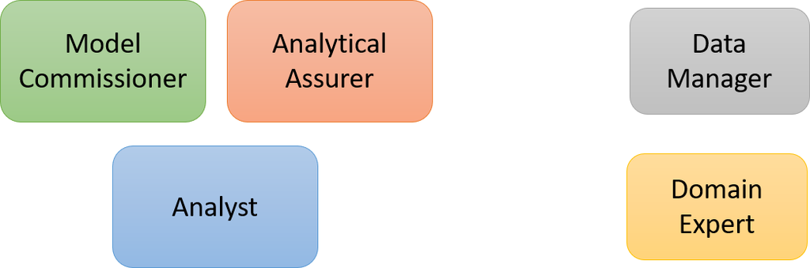

Figure 1.15: System design that relies too much on the opinion of any one member of the team will not work effectively, being unsatisfactory for all.

- Problem Identification
  - What is the problem that needs to be solved? Is predictive modelling the right way to solve that problem? What requirements, constraints and goals should the system have? Have similar problems been solved in the past? How will the resulting model be evualated?
- Data Collection
  - What data exists in this problem area? What data can be obtained? What quality and quantity is needed? This may look very different depending on whether the data needed is labelled, unlabeled, already collected or unstructured.
- Exploratory Analysis
  - What does the data look like? What parts of the data are important? How well do basic benchmark models perform on the problem? What information from the domain expert could inform our model design choices?
- Model Design
  - Using what is known about the data, design different model structure using a range of methods. Test models and improve performance using statistical and machine learning knowledge.
- Model Evaluation
  - How do different model choices compare against the objectives of the system? What are the trade-offs between the different choices? Which align best with what the model commissioner want? Does further data collection / modelling need to be completed?
- Deployment and Maintenanence
  - Models are not created for the sake of it. How will the model predict in practice? How will users interact with the model? How does the model performance change over time?

Each of the different steps above require input from different people involved in the system.

The model engineer cannot ignore the requirements of the commissioner, the knowledge of the domain expert, or the data limitations from the data manager.

We need our analysis to be as reproducible as possible in order to ensure quality. Reproducible Analytical Pipelines (RAP) support the development of reproducible systems. While there are additional challenges for reproducibility in predictive modelling (discussed in module 6). For more information on RAP in general, see [the GSS pipelines page](https://gss.civilservice.gov.uk/reproducible-analytical-pipelines/).

## 3.1 Discussion

**Question**

Who is responsible for the quality of a model?

**Answer**

There is particular responsibility on the analytical assurer in the process, however, every member of the team plays a role in ensuring a good quality model is appropriate.

Adequate resources need to be allocated to ensure quality.

The analyst needs to be aware of appropriate quality standards.

The analytical assurer needs to be empowered to raise concerns, and support improvements to the analysis.

# 4 Model Families

Throughout this course we will discuss common challenges in predictive modelling. To do this we will first need to introduce some common model types used. This will allow us to understand challenges in modelling with more depth, and provide more tangible model recommendations.

There are a wide range of techniques used in this field, with important considerations to be taken into account for each. We cannot cover all techniques, steps in data processing or evaluation. We will introduce four different types of models instead. This is not intended to be a detailed learning material for the model types, but should give an intuition and further resources for each kind.

We will discuss the models in the context of a supervised learning task, where we are predicting values for new data points using a model trained on labelled data (ground truths). To simplify the explanations we will use a binary classification task, such as deciding “yes” or “no” to the question “did an individual buy an ice cream on a given day?”.

## 4.1 Information-Based Models

The first type of model we will look at is the “information-based”.

The most well known information based model is a decision tree model.

The model learns rules which split the data into different groups, one variable at a time. Given a data point and the rules of the model we can predict whether or not the individual bought an ice cream.

The model decides how to split the data based on a criteria. This criteria is related to the amount of information produced by a given split. We want to partition a given variable in a way that produces as many of one label value in one side of the split and as many of the other label value in the other split.

How we decide a split in the decision tree is what makes this a learning algorithm, rather than some expert writing the rules themselves, we use an algorithm to learn the best split.

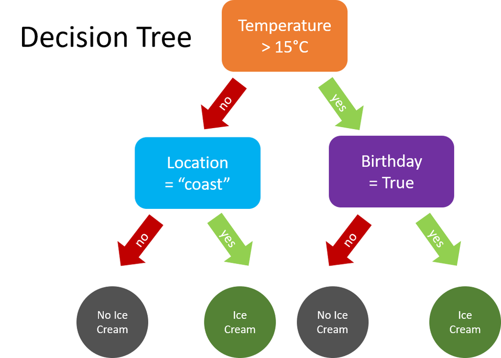

Figure 1.16: Decision trees let us split out data based on different values. Following all the splits will give us a decision on the prediction.

Pros:

- The rules found by the algorithm are easy for humans to understand. We can understand why each prediction was made, and can interrogate the model.
- Complex relationships can be modelled
- They can handle a range of data types with minimum processing required

Cons:

- Decision trees can easily make rules for the specific data it was trained on, not necessarily general trends. This is called [“overfitting”]
- Small changes to the training data will create potentially large differences in the rules found, meaning the model may not be robust.

Extensions and further reading:

- Many decision trees can be used together in an ensemble, which can improve predictive performance. For further information [scikit-learn’s ensemble documentation](https://scikit-learn.org/stable/modules/ensemble.html) is excellent.
- There are a range of criteria to decide how to split a variable. Some include:
  - [Gini Impurity for Decision Trees](https://victorzhou.com/blog/gini-impurity/), * [lecture slides on Information Gain](https://homes.cs.washington.edu/~shapiro/EE596/notes/InfoGain.pdf)
  - [Variance Reduction video for regression](https://www.youtube.com/watch?v=i5wGWV5H7oM)

## 4.2 Similarity-Based

Similarity-based models work under the premise that new data points which are similar to others should have the same outcome.

This means that we need a way to compare data points, often using some method of distance.

Common models which are similarity-based are k-Nearest Neighbour (kNN) models, and Support Vector Machines.

When using these types of models we often refer to data “space” which is defined by each of the variables in the data set. We can then use the distances between points in this space to measure similarity and learn rules that will help us predict new data.

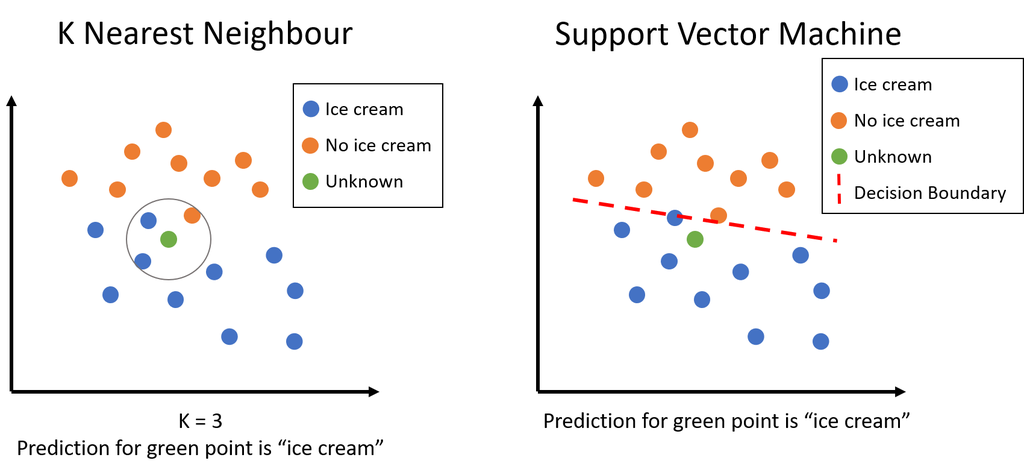

Figure 1.17: (Left) The k-nearest neighbour algorithm predicts the new data points outcome based on the majority outcomes of it’s k-nearest outcome points. (Right) The support vector machine learns a decision boundary that separates the different training data outcomes, classifying the new point based on which side of the boundary it falls.

Pros:

- Modelling data in space allows us to change the space to represent a wide range of possible relationships
- Intuitive to explain models visually

Cons:

- Finding a space (feature engineering) to represent the data can be challenging

Extensions and further reading:

- The K-Nearest Neighbour algorithm demonstrates the challenges of using distances and similarity to classify outcomes. [This blog gives a good overview of the method and considerations](https://kevinzakka.github.io/2016/07/13/k-nearest-neighbor/).
- Support Vector Machines are a very popular classical model, more details with visualisation and R implementation can be found [in this article](http://uc-r.github.io/svm).

## 4.3 Probability-Based

We can frame prediction tasks as probabilities, what is the probability of a certain outcome? There are a range of ways to do this, but the fundamental concept is that by calculating the probability of some event occurring in the seen data, we can work out how likely it is to occur in the new unseen data. More complex probability-based models allow us to encode what we know about probability distributions and model parameters to estimate an outcome.

Three common probability-based models are:

- Naïve Bayes Classifier
- Logistic Regression
- Bayesian Networks

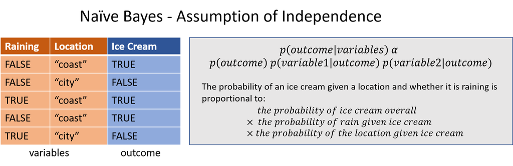

Figure 1.18: This figure gives a very brief overview of what is important in a Naïve Bayes prediction model. The model reworks Bayes rule to allow probability to be calculated through counts of the known data.

Having probabilities involved in a model can help us have different degrees of confidence in a model. If there is a high probability score produced that an individual is having ice cream, the model is more certain about this prediction.

Pros:

- Probabilities allow us to model uncertainty in prediction
- Producing the probability of a range of possible predictions gives us useful assurance information

Cons:

- We are tied to the relationships assumed in the probability relationships (independence, conditional dependence and so on)

Extensions and further reading:

- The Naïve Bayes model is popular largely due to it’s surprisingly good classification performance given it’s simplicity, [this example walks through the calculations used to make a prediction](https://www.kdnuggets.com/2020/06/naive-bayes-algorithm-everything.html).
- Logistic regression is a powerful tool in modelling, it is discussed in different ways in different domains. [This article gives a minimum explanation of the model with code in R](https://uc-r.github.io/logistic_regression).
- Bayesian Networks allow us to explore relationships between variables using directed acyclical graphs, increasing the complexity we can model conditionally. [This article gives a description and relevant diagrams and R code.](https://kevintshoemaker.github.io/NRES-746/BayesianNetworks-1.html)

## 4.4 Error-Based

Error-based models follow the following principle:

> A good model is one which minimises the difference between the predicted outcome and ground truth

which at surface value may raise the question: “shouldn’t all predictive models do that?”, and you would be right. However, error-based models do this explicitly. Instead of calculating the probabilities, similarities or some splitting criteria, an error-based model will have a set of possible parameter values, the best possible parameters for the problem are found which minimise the error.

This can be done in a number of ways:

- start with random parameters then iteratively update them until a best solution is found which minimises the error
- analytically solve an equation to find the perfect best parameter
- approximate the distribution of parameters and find the best values

And this is quite dependent on what we mean by “error”, which can be defined in a range of ways. Consider why
$$error = true - predicted$$
might be a problem for multiple predictions (hint: what if we have negative and positive errors together?).

Common types of error-based models:

- Linear regression (and other generalised linear models)
- Neural Networks (note that some methods can be multiple types of model, for example logistic regression both minimises a loss function to fit it, and calculates probabilities)

We typically refer to the error in these types of models as the “loss function”. It is a function because we give it parameter values (such as a gradient and intercept) and it returns us a value, the error or loss, of the resulting model.

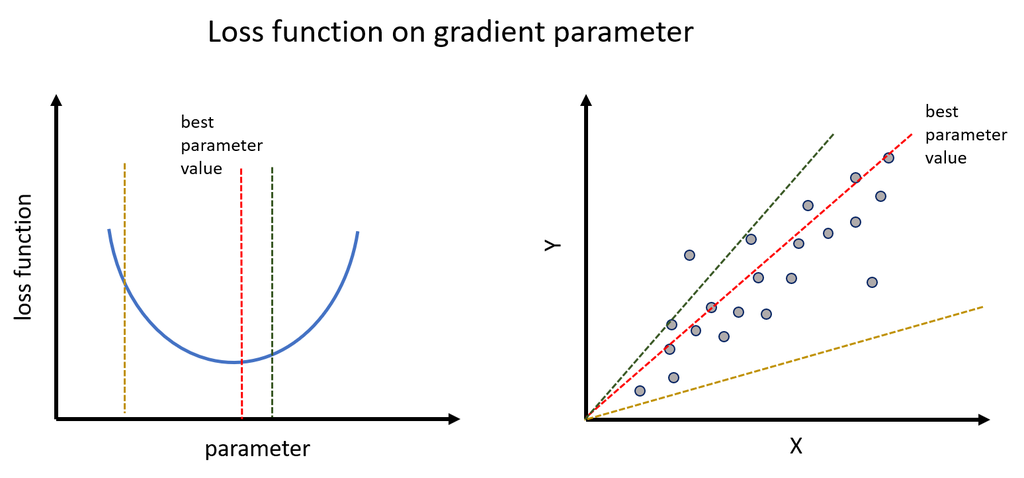

Figure 1.19: The error produced for a range of parameter values is calculated. The parameter which minimises the loss function is chosen as the best fit. When we have many parameters we need to search through different parameter values to find the best performing combination.

Pros:

- Using a loss function gives us a wide range of potential models we can fit and find an approximate solution for.
- We can align our goal and loss function to train a model with our preferred method for evaluating it’s performance.

Cons:

- Our models may be overfit to training data easily if not taken into account.
- Our models can underfit severely if a local optimum is found.

Extensions and Further Reading:

- Loss functions are an important concept for more advanced machine learning models, however, they are also useful for understanding different implimentations of linear regression. [This blog walks through key ideas about loss functions](https://algorithmia.com/blog/introduction-to-loss-functions).
- This [book segment](https://jermwatt.github.io/machine_learning_refined/notes/3_First_order_methods/3_6_Descent.html) explain gradient descent, a very common method for minimising loss functions.
- Logistic Regression uses a cost function (equivalent to a loss function) to fit best parameters to a probability model. [This document walks through the model’s design with supporting Python code.](https://ml-cheatsheet.readthedocs.io/en/latest/logistic_regression.html)

## 4.5 Discussion

**Question**

Which model family should I use?

**Suggestion**

It’s not easy to determine what the best model to use is before testing it out. Some model types will have benefits (such as producing a probability) that may be relevant for our application which may give us a preference.

All our models are “function approximators”, there is some true relationship we are trying to model. We are unlikely to ever find the true relationship, so our best chance is to try a range of ways to approximate the function.

The only way to conclusively know which model is best for your application is to determine what you value from a model, then evaluate it against those metrics.

# 5 Summary

In this module we have covered some fundamental concepts relevant to predictive modelling. These are useful to understand and frame our modelling task, but do not yet prepare us to quality assure models.

The key takeaways from this module are:

- Predictive modelling is a type of analysis covered by the [Aqua Book guidance for analysis in government](https://assets.publishing.service.gov.uk/government/uploads/system/uploads/attachment_data/file/416478/aqua_book_final_web.pdf), the cross government best practice document.
- Predictive modelling is at a high level an optimization task. There is an objective to be maximised with constraints that can prevent high performance.
- There are significant differences between predictive modelling tasks and inference. It’s crucial to recognise what the goals of the model is, which will change how we view interpretability, evaluation and performance.
- There are a range of roles that need to be filled when a model is created. In particular the Aqua book has a model commissioner, analytical assurer and analyst. We will also need to take into account the roles of the data manager/owner and domain experts to get the best out from our model.
- Predictive modelling algorithms can be diverse in their structure. A basic understanding of different model types is important to understand how we can ensure the quality of the models, or compare different models.

In the next chapter we will look at a range of concepts that are useful to be aware of that shape modelling choices, and how we can use them to assure the quality of a model design.